# R Análisis Numéricos Eddy Herrera Daza

##Ejercicios

```r
library(pracma)
library(Matrix)
```

```r
setwd("C:/Users/auditorio/Documents/analisis_numerico/parciales/parcial1")
```

1. Para el siguiente ejercico, instale el paquete “pracma”
1. Revise las siguientes funciones con la matriz del ejercicio 2
2. Evalue la matriz de transición para el método $\textbf{SOR}$

```r
n = 4
D1<-eye(n, m = n)
D2<-ones(n, m = n)
D3<-zeros(n, m = n)

print(D1)
```

```
     [,1] [,2] [,3] [,4]
[1,]    1    0    0    0
[2,]    0    1    0    0
[3,]    0    0    1    0
[4,]    0    0    0    1
```

```r
print(D2)
```

```
     [,1] [,2] [,3] [,4]
[1,]    1    1    1    1
[2,]    1    1    1    1
[3,]    1    1    1    1
[4,]    1    1    1    1
```

```r
print(D3)
```

```
     [,1] [,2] [,3] [,4]
[1,]    0    0    0    0
[2,]    0    0    0    0
[3,]    0    0    0    0
[4,]    0    0    0    0
```

2. Dada la siguiente matriz, utilice las funciones del paquete para descomponer la matriz $A=L+D+U$ (Jacobi)

[output not shown]

2. Utilice la función itersolve(A, b, tol , method = “Gauss-Seidel”) y solucionar el sistema asociado a la matriz $A$ con $b=[1.45,3,5.12,-4]^{t}$ con una tolerancia de $1e^-9$

```r
B = matrix(c(1.45,3,5.12,-4), nrow=n, byrow=TRUE)
print("B")
```

```
[1] "B"
```

```r
print(B)
```

```
      [,1]
[1,]  1.45
[2,]  3.00
[3,]  5.12
[4,] -4.00
```

```r
solucion = itersolve(A, B, x0=c(1,2,1,1), tol=1e-9 , method = "Gauss-Seidel")
print(solucion)
```

```
$x
[1] -2.842399e+196  2.194379e+196  1.238980e+196
[4] -2.200084e+197

$iter
[1] 1000

$method
[1] "Gauss-Seidel"
```

3. Genere 5 iteraciones del método de Jacobi, calcular error relativo para cada iteracion

```r
MetodoJacobi = function(A, b, x0, tol){
  xk = matrix(x0)

  contador = 0

  repeat{
    i = matrix(b - ((L+U)%*%xk))
    D1 = solve(D)
    xk1 = D1%*%i
    cat("Error ", contador, " ", norm(xk1-xk,"F") / norm(xk), "\n")
    xk = xk1
    contador = contador + 1
    if (contador == tol){
      break
    }
  }
  cat("Solucion con 5 iteraciones: ", xk, "\n")
}
x0 = c(1,2,1,1)
MetodoJacobi(A, B, x0, 5)
```

```
Error  0   4.118073
Error  1   1.014324
Error  2   2.830197
Error  3   1.268594
Error  4   2.063461
Solucion con 5 iteraciones:  -4.627352 -1.394185 -4.90428 -89.51575
```

```r
A = matrix(c(4, -1, -1, -1, -1, 4,
-1, -1, -1, -1, 4, -1,
-1, -1, -1, 4), nrow=4, byrow=TRUE)
A
b = c(1, 5, 1.5,-2.33)
b
```

[output not shown]

d Comparar con la solución por defecto

```r
solucion<- solve(A,b)
```

1. Pruebe el siguiente algoritmo con una matriz $A_{3}$, modifiquelo para quue $a_{ii}=0$ para todo $i$

```r
trilManual = function(M, k = 0){
  if (k == 0){
    M[upper.tri(M, diag = TRUE)] = 0
  } else {
    M[col(M) >= row(M) + k + 1] = 0
    M[col(M)==row(M)] = 0
  }
  return(M)
}

M = matrix(c(2,3,4,1,2,3,5,6,7), nrow = 3)
print("M: ")
```

```
[1] "M: "
```

```r
print(M)
```

```
     [,1] [,2] [,3]
[1,]    2    1    5
[2,]    3    2    6
[3,]    4    3    7
```

```r
print("Tril M: ")
```

```
[1] "Tril M: "
```

```r
print(trilManual(M, k = 1))
```

```
     [,1] [,2] [,3]
[1,]    0    1    0
[2,]    3    0    6
[3,]    4    3    0
```

2. Implemente una función en R para que dada una matriz $A$ se obtenga una matriz diagonal $D$ donde en la diagonal estan los mismo elementos de A

```r
M = matrix(c(2,3,4,1,2,3,5,6,7), nrow = 3)
print("M: ")
```

```
[1] "M: "
```

```r
print(M)
```

```
     [,1] [,2] [,3]
[1,]    2    1    5
[2,]    3    2    6
[3,]    4    3    7
```

```r
MatrizDiagonal = function(M){
  M[col(M)!=row(M)] = 0
  return(M)
}

print("Diagonal M: ")
```

```
[1] "Diagonal M: "
```

```r
print(MatrizDiagonal(M))
```

```
     [,1] [,2] [,3]
[1,]    2    0    0
[2,]    0    2    0
[3,]    0    0    7
```

4. Cree una función que cuente el número de multiplicaciones en el método directo de Gauss Jordan, para resolver un sistema de $n$ ecuaciones y pruebelo para $n=5$

```r
#Suponemos que el determinante de A != 0
numeroMultiplicaciones = function(A, b){
  multiplicacion = 0
  n = nrow(A)

  Ab = cbind(A, b)
  print(Ab)

  for (i in 1:(n-1)) {
    if (Ab[i, i] == 0){
      f = which(Ab[i, ] != 0)[1]
      Ab[c(i, f), ] = Ab[c(f, i), ]
    }
    for (k in (i+1): n){
      Ab[k, ] = Ab[k, ] - Ab[k, i] / Ab[i, i]*Ab[i, ]
      multiplicacion = multiplicacion + 2*(ncol(Ab))
    }
  }

  x = rep(NA, times = n)
  x[n] = Ab[n, n+1] / Ab[n, n]
  multiplicacion = multiplicacion + n + 1

  for (i in (n-1):1){
    x[i] = (Ab[i, n+1] - sum(Ab[i, (i+1):n] * x[(i+1):n])) / Ab[i, i]
    multiplicacion = multiplicacion + 2*(n-2)
  }
  cat("Numero de multiplicaciones: ", multiplicacion, "\n")
  return(x)

}

A = matrix(c( 0, 2, 3, 3, 3,
              -5, -4, 1, 4, 5,
              0, 0, 0, 3, 7,
              -4, -7, -8, 9,7,
              3, 4, 5, 5, 6), nrow=5, byrow=TRUE)

b = matrix(c(1,0,0,0,1), nrow=5, byrow=TRUE)

print(numeroMultiplicaciones(A, b))
```

```
     [,1] [,2] [,3] [,4] [,5] [,6]
[1,]    0    2    3    3    3    1
[2,]   -5   -4    1    4    5    0
[3,]    0    0    0    3    7    0
[4,]   -4   -7   -8    9    7    0
[5,]    3    4    5    5    6    1
Numero de multiplicaciones:  150
[1] -0.28978300  0.44032550 -0.08137432  0.21202532
[5] -0.09086799
```

5. Dado el siguiente sistema:

```r
#alpha > 1 + 1
# 2 > beta + 1
library(plot3D)


beta = 0
alpha = 3

A = matrix(c(2, 0, 1,
             beta,2 , -1,
             -1, 1, alpha), nrow=3, byrow=TRUE)

B = matrix (c(1,2,1),nrow=3, byrow=TRUE)

Ab = cbind(A,B)
print(Ab)
```

```
     [,1] [,2] [,3] [,4]
[1,]    2    0    1    1
[2,]    0    2   -1    2
[3,]   -1    1    3    1
```

```
Error  1   0.6066758
Solucion iteracion  1 :  -1   2.5   0
Error  2   0.6511807
Solucion iteracion  2 :  0.5   1   -0.8333333
Error  3   0.4974424
Solucion iteracion  3 :  0.9166667   0.5833333   0.1666667
Error  4   0.4558265
Solucion iteracion  4 :  0.4166667   1.083333   0.4444444
Error  5   0.198977
Solucion iteracion  5 :  0.2777778   1.222222   0.1111111
Error  6   0.1571815
Solucion iteracion  6 :  0.4444444   1.055556   0.01851852
Error  7   0.0849292
Solucion iteracion  7 :  0.4907407   1.009259   0.1296296
Error  8   0.05179846
Solucion iteracion  8 :  0.4351852   1.064815   0.1604938
Error  9   0.0258892
Solucion iteracion  9 :  0.4197531   1.080247   0.1234568
Solucion:  0.4197531 1.080247 0.1234568 , con  10  iteraciones:
```

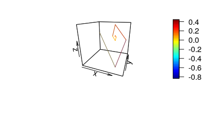

```r
#Punto b
x = 0
y = 0
z = 0

diagonal = function(M){
  M[col(M)!=row(M)]= 0
  return(M)
}

MetodoJacobi3D = function(A, b, x0, tol){
   xk = matrix(x0)

  D = diagonal(A)
  L = tril(A, k=-1, diag = FALSE)
  U = triu(A, k=1, diag = FALSE)

  contador = 1
  repeat
  {
    i = matrix(b-((L+U)%*%xk))
    D1 = (solve(D))
    xk1 = D1%*%i
    cat("Error ",contador," ",norm(xk1-xk,"F")/norm(xk),"\n")
    xk = xk1

    x[[contador]] = xk[1]
    y[[contador]] = xk[2]
    z[[contador]] = xk[3]
    cat("Solucion iteracion ", contador,": ",x[[contador]]," ",y[[contador]]," ",z[[contador]],"\n")
    contador = contador + 1

    if(contador == tol)
      break
  }
  #Punto c
  lines3D(x, y, z, colvar = z, col = NULL, add = FALSE, theta = 20, phi = 20)
  cat("Solucion: ", xk, ", con ", tol ," iteraciones: ","\n")
}

x1 = c(1,2,3)
MetodoJacobi3D(A, B, x1, 10)
```

```r
n = 4
A = matrix(c(-8.1, -7, 6.123, -2, -1, 4,
-3, -1, 0, -1, -5, 0.6,
-1, 0.33, 6, 1/2), nrow=n, byrow=TRUE)
b = matrix(c(1.45,3,5.12,-4), nrow=n, byrow=TRUE)

print("A: ")
```

```
[1] "A: "
```

```r
print(A)
```

```
     [,1]  [,2]   [,3] [,4]
[1,] -8.1 -7.00  6.123 -2.0
[2,] -1.0  4.00 -3.000 -1.0
[3,]  0.0 -1.00 -5.000  0.6
[4,] -1.0  0.33  6.000  0.5
```

```r
Ab = cbind(A, b)

#Diagonales

L = tril(A, k = -1, diag = FALSE)
U = tril(A, k = 1, diag = FALSE)

#QR
gs = gramSchmidt(A)
(Q = gs$Q); (R = gs$R)
```

```
           [,1]       [,2]        [,3]        [,4]
[1,] -0.9850983 -0.1436118 -0.04743408 -0.08189671
[2,] -0.1216171  0.9447015 -0.30403534 -0.01763100
[3,]  0.0000000 -0.1978603 -0.65697987  0.72748111
[4,] -0.1216171  0.2185544  0.68825138  0.68099435
        [,1]     [,2]      [,3]       [,4]
[1,] 8.22253 6.369086 -6.396608  2.0310050
[2,] 0.00000 5.054072 -1.412812 -0.6669168
[3,] 0.00000 0.000000  8.036075  0.3488413
[4,] 0.00000 0.000000  0.000000  0.9584103
```

```r
print("Q*R =  A")
```

```
[1] "Q*R =  A"
```

```r
print(Q%*%R) # = A
```

```
     [,1]  [,2]   [,3] [,4]
[1,] -8.1 -7.00  6.123 -2.0
[2,] -1.0  4.00 -3.000 -1.0
[3,]  0.0 -1.00 -5.000  0.6
[4,] -1.0  0.33  6.000  0.5
```

1. Determinar numéricamente la intersección entre la circunferencia $x^2 + y^2 = 1$ y la recta $y = x$. Usamos una aproximación inicial $(1,1)$. Utilice el pauqte BB y la función BBsolve() del paquete,grafique la solución

```r
library(BB)
ecuacion = function(x){
  n = length(x)
  F = rep(NA, n)
  F[1] = x[1] - x[2]
  F[2] = x[1]^2 + x[2]^2 - 1
  F
}

aproximacion = c(1,1)
sol = BBsolve(par = aproximacion, fn = ecuacion)
```

```
  Successful convergence.
```

```r
sol$par
```

```
[1] 0.7071067 0.7071068
```

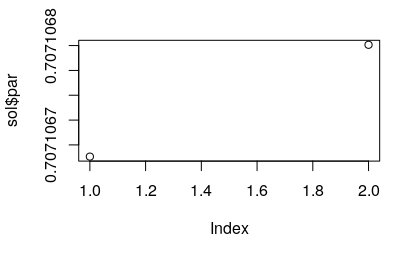

```r
plot(sol$par)
```

[figure not shown]

```r
plot(ecuacion)
```

b Analizar y comentar el siguinte código

```r
trigexp = function(x) {
n = length(x)
F = rep(NA, n)
F[1] = 3*x[1]^2 + 2*x[2] - 5 + sin(x[1] - x[2]) * sin(x[1] + x[2])
tn1 = 2:(n-1)
F[tn1] = -x[tn1-1] * exp(x[tn1-1] - x[tn1]) + x[tn1] *
( 4 + 3*x[tn1]^2) + 2 * x[tn1 + 1] + sin(x[tn1] -
x[tn1 + 1]) * sin(x[tn1] + x[tn1 + 1]) - 8
F[n] = -x[n-1] * exp(x[n-1] - x[n]) + 4*x[n] - 3
F
}
n = 10000
p0 = runif(n) # n initial random starting guesses
sol = BBsolve(par=p0, fn=trigexp)
```

```
  Successful convergence.
```

```r
sol$par
```

[output not shown]

[output cut: 24 more lines]

8. Demuestre y realice varias pruebas que la matriz de transición por el método de Gauss-Seidel esta dada por $T=(-D^{-1}U)(I+LD^{-1})^{-1}$

```r
N = 3
A = Diag(rep(3,N)) + Diag(rep(-2, N-1), k=-1) + Diag(rep(-1, N-1), k=1)
x0 = rep(0, N)
b = c(4,5,6)

itersolve(A, b, tol = 1e-9 , method = "Gauss-Seidel")
```

```
$x
[1] 3.266667 5.800000 5.866667

$iter
[1] 26

$method
[1] "Gauss-Seidel"
```